## Study Focus and Distraction Patterns

Staying focused while studying is not always easy, especially when there are different kinds of distractions around. In this report, I look at my own study sessions to see how factors like phone use, study time, and types of distraction may relate to my level of focus.

To analyse the data, I use simple summary statistics and bar charts. Variables such as focus level, phone use, and distraction type are compared using frequency counts. This helps to identify patterns and makes it easier to see how different factors might be connected to focus.

I also included extra variables like phone use and types of distraction, instead of only recording study time. This makes the data more meaningful and allows a better understanding of what may affect my concentration during study sessions.

In total, 22 study sessions were recorded. On average, each session lasted about 90.8 minutes, with the longest session reaching 240 minutes. This suggests that most study sessions were of moderate length, with some longer sessions as well.

### bar chart 1

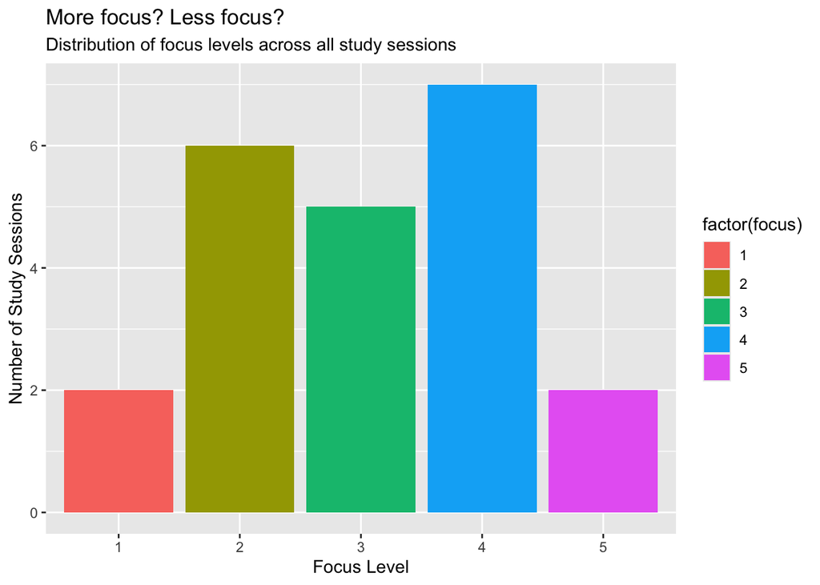

This bar chart shows how focus levels are distributed across all study sessions.

It can be seen that certain focus levels occur more frequently than others, suggesting that my focus is not evenly distributed.

In particular, focus level 4 appears the most common, indicating that I was generally able to maintain a reasonable level of concentration during most sessions.

However, higher focus levels appear less frequently, which may suggest that it is difficult to consistently maintain a very high level of concentration over time.

Phone use and other distractions may also contribute to lower focus levels, suggesting that external factors could influence how well I concentrate during study sessions.

### bar chart 2

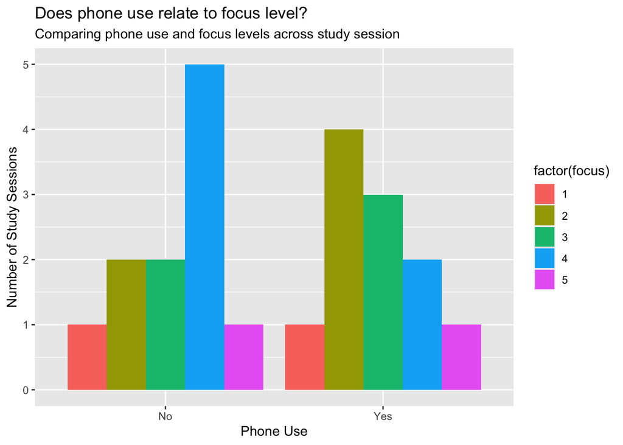

This chart compares focus levels between study sessions with and without phone use. Each group represents whether a phone was used, while the colors show different focus levels.

From the chart, sessions without phone use appear to have slightly higher counts of higher focus levels, while sessions with phone use show more variation across lower and mid-level focus.

This suggests that phone use may be associated with reduced concentration, although the pattern is not entirely consistent. One possible explanation is that checking or interacting with a phone may interrupt attention, making it harder to maintain a higher level of focus during study sessions.

However, since the sample size is relatively small, this relationship should be interpreted with caution.

### bar chart 3

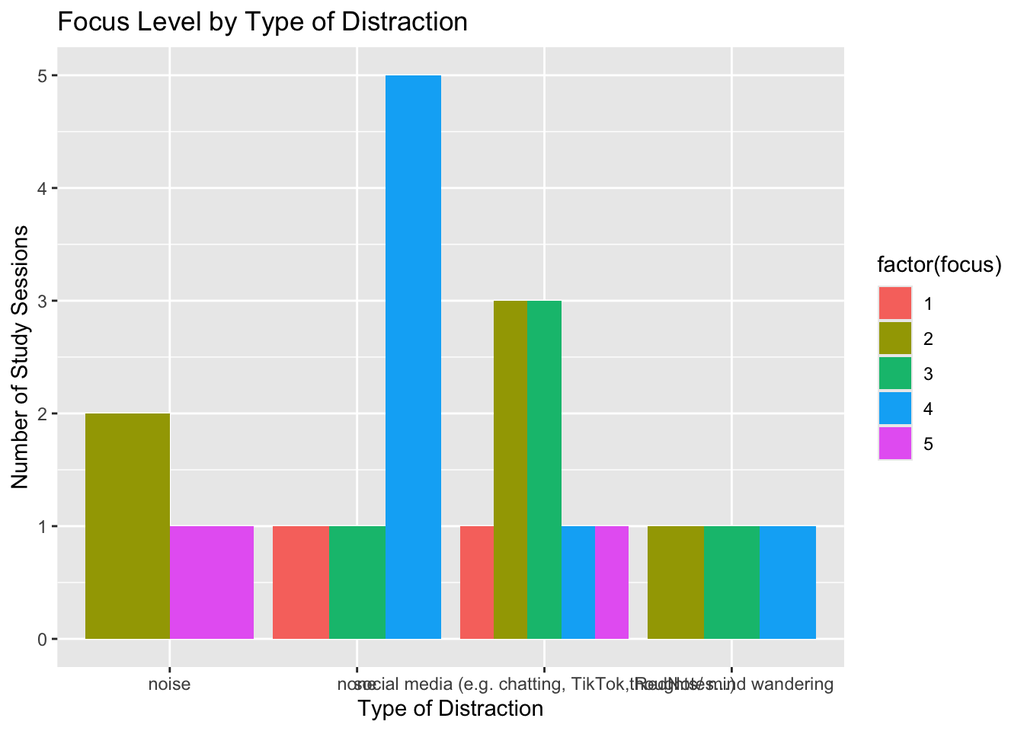

This chart shows how different types of distraction relate to focus levels across study sessions.

Overall, the relationship between distraction type and focus is not very strong or consistent. However, some types of distraction appear to be associated with slightly lower focus levels compared to others, while a few categories still show moderate levels of focus.

This may suggest that not all distractions have the same impact on concentration. Some distractions may interrupt attention more directly, while others might be less disruptive depending on the situation or how the study session is structured.